# Exploring Next Generation Sequence data with the Linux command line

M Timothy Rabanus-Wallace

# Introduction and setup

Most of you will be familiar with operating systems like Windows or MacOS. *Linux* is also an operating system: it is used to manipulate files, run programs, and generally serve as an interface between hardware, software, and users. But Linux is used by typing text into a console, just like R. At first, this is quite uncomfortable and frustrating, but it becomes natural quickly, and the advantages are *enormous*. With Windows and MacOS, simple file manipulations like moving a group of files from one directory to another is easy. But what about renaming all your 542 holidays photographs to “Tim-holiday-2019-1.jpg”, “Tim-holiday-2019-2.jpg”, “Tim-holiday-2019-3.jpg” … etc? On Windows this would take a whole day. In Linux I could write:

```bash
n=1; for i in $(ls *.jpg); do mv $i Tim-holiday-2019-${n}.jpg; n=$((n+1)); done
```

And it would rename all the photographs in about half a second. Of course, learning how a command like this works takes a bit of time, so there is a trade-off: It takes time to learn, but once you can do it, many tasks that can occupy people for hours become very fast and easy.

In bioinformatics, this kind of task comes up every day. Bioinformatics often involves running programs thousands or millions of times on thousands or millions of files, in all sorts of orders and combinations. So most bioinformaticians love Linux. Linux is a free version of the professional system *Unix*, but it is open source, more frequently updated and improved, more flexible, and generally just better.

# Getting set up

# First steps

First, let me just prove to you that Linux is an operating system. In Linux we are always working in a directory. To see what your current *working directory* is, type and run this function:

```bash
pwd
```

“pwd” stands for “print working directory”.

To see all the files and directories in your working directory run this function:

```bash
ls
```

… which is short for “list”. You will see all the directories you know from the course work so far, something like this:

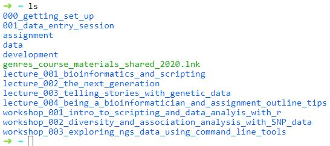

```bash
ls workshop_002_diversity_and_association_analysis_with_SNP_data
```

Now try using the `cd` function (“change directory”) to change your working directory to today’s workshop directory. After that, run `pwd` to confirm you changed directory, and `ls` to look at what’s in the new working directory. Like this (type and run them one at a time):

```bash
cd workshop_003_exploring_ngs_data_using_command_line_tools

pwd

ls
```

To move back to the old working directory, run the following command. The `..` always refers to the parent of the current working directory, so if you are in a directory “/home/user/documents”, then `cd ..` will change your working directory to “/home/user”.

```bash
cd ..
```

Notice how Linux functions are a bit similar to R functions: They have a name (like “cd” or “ls”), and you give them arguments (like the name of a directory). The difference is that in Linux, we don’t put the arguments in brackets. However, they often do the same things! For instance, the R function `list.files()` does exactly what the Linux function `ls` does. Remember the `seq()` command in R? For instance `seq(from = 0 , to = 10 , by = 2)` would produce “0 2 4 6 8 10”. Well, try this in the Linux terminal:

```bash
seq 0 2 10
```

Notice it does the same! The arguments (0, 2, and 10) are just in a different order. The point is, once you learn one language, the second one is a lot easier.

There are a lot of Linux functions that exist for copying, moving, editing, creating files/directories etc. But today is about bioinformatics, so we’ll instead focus less on operating system functions, and more on functions that process the contents of files. Specifically, files that contain Next Generation Sequencing data. But as a starting point, we can use a simple text file to demonstrate. The function `cat` (“*cat*enate”) will print the contents of a file to the terminal. The file we will print out is in the “data/” directory and it is called “poem.txt”, so we will run `cat`, and give it the path to find that file (“data/poem.txt”).

```bash
cat data/poem.txt #remember use <tab> to auto-complete as you type!
```

## Pipes and flags

So you should be seeing lines of text from a poem in the terminal. Now the terminal is only where the text goes by default. We could also save it into a file, for example. Or—and this is one of the keys to why Linux is so magical—we can send it *into another command*. If we write a `|` symbol (called a “pipe”) after a command, the result will not go to the screen, it will go into the second command.

For example, there is a function `wc` which stands for “word count”, which counts the lines, words, and characters in text. If we *pipe* the output of `cat data/poem.txt` into `wc`, it will count those things in the poem. Try this:

```bash
cat data/poem.txt | wc
```

Ok, the poem has 46 lines, 366 words, and 2063 characters.

I can actually modify the output of `wc` to *only* print the information I want, and I do it using a *flag*. A flag is typed after the function name, and modifies what the function does. For instance, the `-w` flag for `wc` tells it only to print the word count, and the `-l` flag tells it only to print the line count. Try these:

```bash
cat data/poem.txt | wc -l

cat data/poem.txt | wc -w

cat data/poem.txt | wc -c
```

```bash
cat data/poem.txt | grep 'the'
```

#### Exercises

1. Change working directory into “data”
2. List the files in the new working directory
3. List the files again, but add the flag `-l` to the command. This flag will tell the function `ls` to provide (l)ong information about the files
4. Do it again, but add a *second* flag, `-h`. This will change the file sizes to (h)uman readable format. Which is the biggest file?
5. *Without changing the working directory* list the files in the parent directory
   - HINT: Remember, to refer to a parent directory, use `..`
6. Change directory back to the parent directory
7. Print the contents of poem.txt using `cat`
8. Use `grep` to select only the lines of the poem containing the pattern “and”
9. The above command matches “and”, but not “And”, which sometimes occurs at the start of lines. The flag `-i` for grep will tell it to (i)gnore cases, so it will match both. Add the `-i` flag to `grep` in the previous command
10. Extend that command to count the number of lines containing the pattern “and” (or “And”)
    - HINT: You will need to use another pipe, and the function `wc`

# Getting friendly with NGS data

## Counting reads in a fastq file

Even with the few simple commands we have learned, it is possible to do some basic processing on NGS data. We’ll first use `cat`, `grep`, and `wc` to count the numbers of reads in the standard NGS reads file which is in the format “fastq”.

Just take a second to remind yourself of the big picture, and where these “reads” fit in the big picture. They are the raw output of a sequencing machine, representing the sequences of bits of DNA that come from (in this case) the genome of a barley plant.

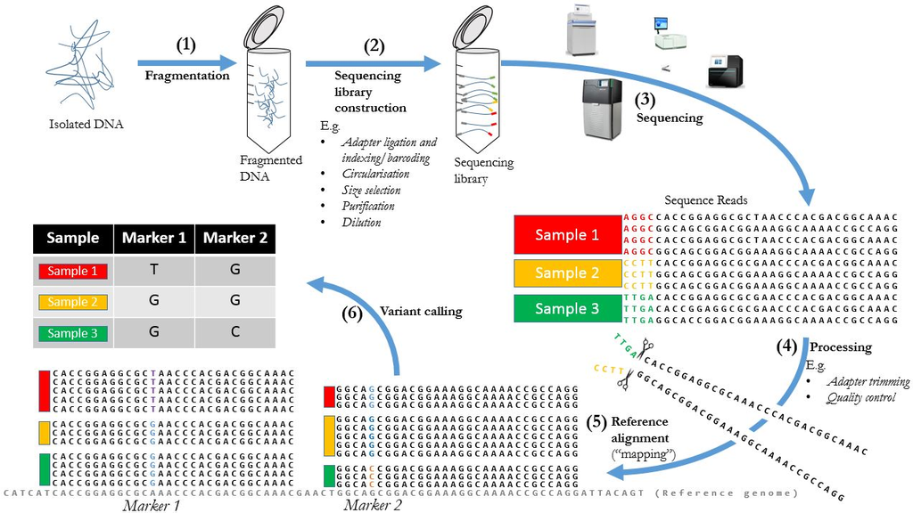

#### Exercise

- The function `head` is *exactly* like `cat`: It prints the contents of a file on the screen. BUT—`head` only prints the first 10 lines. This is great to see what is in the file when the file has millions of lines in it. Use the function `head` to look at the first ten lines of the file “HOR_12”

I got this:

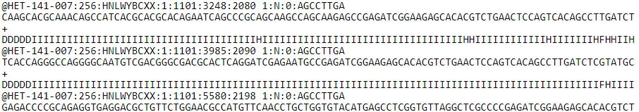

As we learned in the lecture, the lines are in groups of four: The name, the sequence, a “+”, and the qualities (represented as a string of letters).

However, we want to know how many sequences there are, so it would be best to use just one line per sequence. We could use `grep` for that! Notice that the beginning of each read line begins with the code ‘@HET-141-007:256:HNLWYBCXX’ … etc. This is information about the run, and it’s going to be the same for every read in the file, so we could use this as our pattern for `grep` to search for.

```bash
head data/HOR_1251.fastq | grep '@HET-141-007:256:HNLWYBCXX'
```

Now you have a way to produce one line per read. And we already know how a good way to count lines, so:

#### Exercises

1. Count the reads in ‘HOR_1251.fastq’.
   - HINT: Remember `head` will only print 10 lines. Change it to a command that will print all the lines.
2. Count the reads in ‘HOR_1384.fastq’.
   - It is also in the ‘data’ directory.
   - HINT: You will need to first look at the contents and identify a good pattern for `grep` to match. It might not be the same as it was for HOR_1251.fastq.
3. How many sequences in HOR_1384.fastq contain the motif ‘AAGGGGCTGACACTGA’

# Exploring a bam file: First steps in awk.

Once reads are aligned (or “mapped” in bioinfomatics slang) to a reference genome, the information is stored in a .sam file (or its binary-encoded equivalent, a .bam file). To get a feel for what this information really *means* we can view the .sam file’s contents using a specialised viewer that diplays the mapped reads the way we visualised them in the lecture: stacked up on top of the reference genome, so that the nucleotides of the read match up to their aligned positions in the reference.

The program `samtools` contains a visualiser called `tview` to do this, and I’ve created a shortcut function to diplay the alignment in the terminal, by running this command:

```bash
#with variant
samtools_tview_HOR_1251_mapped

#g

#chr1H:10965721
```

Tap (or hold) space to scroll across the genome, and backspace to scroll in the other direction. Perhaps you can find a mapped read … but they are spread out far across the genome, so it may be hard to find some.

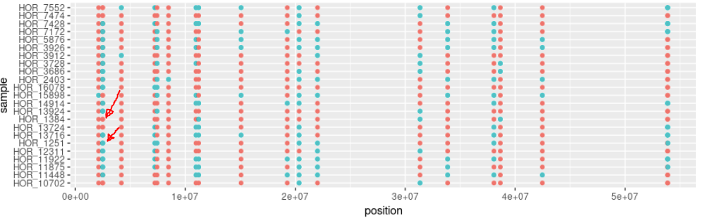

Press question mark (`?`) to get a menu of helpful commands (`<esc>` to exit). Among these is `g`, to jump to a position. Press `g`, and enter the position like this “chr1H:10965721”m then press `<enter>`.

The position will be placed at the left side of the screen so use the arrow keys to move it around. Press the full stop key (`.`) to toggle nucleotide view on and off.

#### Exercises

1. What is the reference genome’s state (nucleotide) at position chr1H:10965721?
2. What state does HOR_1251 have?
3. How many reads mapped at this SNP locus?
4. Are there other sites nearby at which HOR_1251 differs in sequence from the reference?
5. Are there other loci nearby at which reads also mapped?
6. Press `b` to toggle colour by base quality (press `v` to toggle highlighting also if you want). Find some bases of lower quality (green or yellow). Are they randomly distributed across the reads?
7. Close the viewer (`q`), and examine the mapping at the same SNP site for HOR_1384, using the command `samtools_tview_HOR_1384_mapped`.
8. Are there differences between HOR_1348 and the reference at this site?
9. Remember the information stored in a .vcf file relate to the genotype calls in a population. Based on your knowledge of HOR_1251 and HOR_1384, could you fill in these entries on a simplified one-row .vcf file that describes the genotypes:
   - Column 1 (Chromosome name): ____
   - Column 2 (Position number): ____
   - Column 4 (Reference allele): ____
   - Column 5 (Alternative allele): ____
   - Column 10 (Genotype information for HOR_1284 [DP=;GT=]): DP=*;GT=*_
   - Column 11 (Genotype information for HOR_1384 [DP=;GT=]): DP=*;GT=*_

Of course visualisations like this are nice, but they aren’t ideal for a bioinformatician to use for really creative analysis! for that, we need the raw data in .sam format. There is a (slightly simplified) .sam file for HOR_1251, which is in *data/HOR_1251_mapped_to_reference_genome.sam*. Have a look at it quickly using `head`. You should get this:

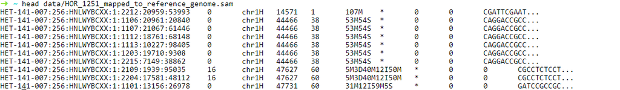

To analyse data in volumes like this (this is actually a small-ish sam file and it still contains 375,609 lines), we need to describe what we want to a computer, via some appropriate language. R is very good up to a limit, but once the volume of data goes from the millions into the billions of rows, faster tools are needed. It’s time to start learning your second programming language, called *awk*. Awk is a beautiful language, and it’s so compact you can actually learn most of its functionality through [Wikipedia](https://en.wikipedia.org/wiki/AWK).